# Fastai Collaborative Filtering with R and Reticulate

Jeremy Howard recently taught the [Fastai Deep Learning for Coders (Part 1)](http://course.fast.ai/) course. This course has a lesson on Collaborative Filtering where he uses MovieLens dataset to demonstrate models for predicting ratings of movies. This content is covered in videos of [lecture 5](http://course.fast.ai/lessons/lesson5.html) and [lecture 6](http://course.fast.ai/lessons/lesson6.html).

This notebook is an attempt to create a R version (using Reticulate package) of the MovieLens python [notebook](https://github.com/fastai/fastai/blob/master/courses/dl1/lesson5-movielens.ipynb) covered in the course. While we can have separate python and R chunks with interoperability using Reticulate, I have tried to do everything in R since it will be easier to use this as standalone R script also. This course uses a library fastai (written by Jeremy) which is a wrapper around PyTorch.

It will be helpful to listen to the lectures before going through this notebook since the concepts of the model and approach are discussed in the lecture and this notebook is just a replication attempt of the material from the course using R.

## Initial Setup

```r
# import R libraries
library(reticulate)
library(ggplot2)
library(dplyr)
library(irlba)
```

In this course, they talk about several cloud GPU options and provided a conda environment fastai in those environments. I am using the Paperspace setup that is covered in [Lesson 1](http://course.fast.ai/lessons/lesson1.html). Reshama Shaik has also listed detailed upto date [instructions](https://github.com/reshamas/fastai_deeplearn_part1/blob/master/tools/paperspace.md) on getting set up in Paperspace. For setting up RStudio server in the same machine, I followed Cloud GPU [setup section](https://tensorflow.rstudio.com/tools/cloud_gpu.html) in TensorFlow for R site (except for the EC2 part).

Since the machine already comes with fastai conda environment, we first need to use the python that is part of the fastai environment and also use the fastai conda environment.

```r
use_python("/home/paperspace/anaconda3/envs/fastai/bin/python", required = TRUE)
use_condaenv("fastai")
py_config()
```

```
python:         /home/paperspace/anaconda3/envs/fastai/bin/python
libpython:      /home/paperspace/anaconda3/envs/fastai/lib/libpython3.6m.so
pythonhome:     /home/paperspace/anaconda3/envs/fastai:/home/paperspace/anaconda3/envs/fastai
version:        3.6.4 |Anaconda, Inc.| (default, Dec 21 2017, 21:42:08)  [GCC 7.2.0]
numpy:          /home/paperspace/anaconda3/envs/fastai/lib/python3.6/site-packages/numpy
numpy_version:  1.13.3

NOTE: Python version was forced by use_python function
```

```r
main = import_main()
bi = import_builtins()
```

The fastai library is located in the folder ~/fastai. So first, we import fastai.learner and fastai.columndata (libraries used in the notebook) from the folder.

```r
# get relevant python imports
fstai_learner = import_from_path("fastai.learner", "../../fastai")
fstai_coldata = import_from_path("fastai.column_data", "../../fastai")
```

These modules import several other modules. So the import command used in the python notebook is directly called below so that all the other modules are also available for use later.

```r
py_run_string("
from fastai.learner import *
from fastai.column_data import *
              ")
```

## Get Data

The ratings dataset has the ratings for different users and movies. The movies dataset has the movie title information.

```r
datapath = "../../data/ml-latest-small/"
ratings = read.csv(paste0(datapath, "ratings.csv"), stringsAsFactors = FALSE)
head(ratings)
```

|  | userId | movieId | rating | timestamp |
| --- | --- | --- | --- | --- |
| 1 | 1 | 31 | 2.5 | 1260759144 |
| 2 | 1 | 1029 | 3.0 | 1260759179 |
| 3 | 1 | 1061 | 3.0 | 1260759182 |
| 4 | 1 | 1129 | 2.0 | 1260759185 |
| 5 | 1 | 1172 | 4.0 | 1260759205 |
| 6 | 1 | 1263 | 2.0 | 1260759151 |

```r
movies = read.csv(paste0(datapath, "movies.csv"), stringsAsFactors = FALSE)
head(movies)
```

|  | movieId | title | genres |
| --- | --- | --- | --- |
| 1 | 1 | Toy Story (1995) | Adventure\|Animation\|Children\|Comedy\|Fantasy |
| 2 | 2 | Jumanji (1995) | Adventure\|Children\|Fantasy |
| 3 | 3 | Grumpier Old Men (1995) | Comedy\|Romance |
| 4 | 4 | Waiting to Exhale (1995) | Comedy\|Drama\|Romance |
| 5 | 5 | Father of the Bride Part II (1995) | Comedy |
| 6 | 6 | Heat (1995) | Action\|Crime\|Thriller |

## Model Fitting

First, the set of user/movie combinations that would be used as validation set is determined. Then, the following parameters are set:

- weight decay (wd)
- Number of factors in embedding `n_factors`

For few of the code snippets below, I have included the python code in comments to show the correspondence between python code and R code with reticulate. In most cases, I just had to do one of the following things to get things to work:

- Replace period in python code with dollar
- If it is a python variable or function, prefix a `py$`
- Explicitly convert an R object into python object when passing to a function using `r_to_py` if needed.
- If a python function requires an integer as argument, then I ensured that an integer is passed as an argument (for example, passing `2L` instead of `2`)

```r
# python code
# val_idxs = get_cv_idxs(len(ratings))
#
val_idxs = py$get_cv_idxs(nrow(ratings))
val_idxs = as.integer(val_idxs)
wd = 2e-4
n_factors = 50L
```

Next a data loader object `cf` and a learner object `learn` is created

```r
# python code
# cf = CollabFilterDataset.from_csv(path, 'ratings.csv', 'userId', 'movieId', 'rating')
#
cf = py$CollabFilterDataset$from_csv(datapath, 'ratings.csv', 'userId', 'movieId', 'rating')
# python code
# learn = cf.get_learner(n_factors, val_idxs, 64, opt_fn=optim.Adam)
#
learn = cf$get_learner(n_factors, val_idxs, 64L, opt_fn=py$optim$Adam)
```

We review the model

```r
learn$model
```

```
EmbeddingDotBias(
  (u): Embedding(671, 50)
  (i): Embedding(9066, 50)
  (ub): Embedding(671, 1)
  (ib): Embedding(9066, 1)
)
```

The model has the following components:

- The vector of `n_factors = 50` for each of `n_users = 671` is represented by a `n_users x n_factors` embedding matrix `u`.
- The vector of `n_factors = 50` for each of `n_movies = 9066` is represented by a `n_movies x n_factors` embedding matrix `i`.
- Users have a bias vector `ub` of length `n_users = 671` and movies have a bias vector `ib` of length `n_movies = 9066`.

Next we fit the model

In Jupyter notebook, a widget shows a nice output of progress. That output doesn’t render properly within RStudio and the html generated document has too much output. For now, I have turned off output and am just storing the final validation loss metric (MSE loss in this case)

```r
paste0("MSE of validation set = ", round(mdlfit[[1]], 3))
```

```
[1] "MSE of validation set = 0.766"
```

Next we compare the predicted and actual ratings for the validation set

```r
yval_preds = learn$predict()
yval=learn$data$val_y
```

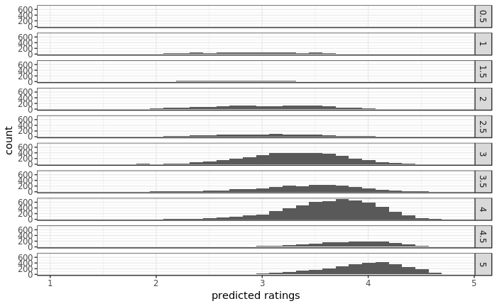

```r
dfplt = data.frame(yval = yval, yval_preds = yval_preds)
ggplot(dfplt) + geom_histogram(aes(x = yval_preds)) + facet_grid(yval ~ .) +
   xlab("predicted ratings") + theme_bw()
```

## Interpretation of Movie Bias

The model uses a sequential numeric id for users and movies, we first get the movie to id mapping from the data object `cf`.

```r
movie2idx = cf$item2idx
movie2idx = unlist(movie2idx)
head(movie2idx)
```

```
  31 1029 1061 1129 1172 1263
   0    1    2    3    4    5
```

```r
idx2movie = as.numeric(names(movie2idx))
names(idx2movie) = movie2idx
head(idx2movie)
```

```
   0    1    2    3    4    5
  31 1029 1061 1129 1172 1263
```

Get the top 3000 movies that got the most ratings

```r
topmovies = ratings %>% group_by(movieId) %>% summarize(cnt = n()) %>% arrange(desc(cnt)) %>% slice(1:3000)
topmoviesidx = movie2idx[as.character(topmovies$movieId)]
topmoviesidx = np_array(topmoviesidx)
```

Get the movie bias variable for the top 3000 movies

```r
# python code
# m=learn.model
# movie_bias = to_np(m.ib(V(topMovieIdx)))
#
m = learn$model
movie_bias = py$to_np(m$ib(py$V(topmoviesidx)))
movie_bias[1:20]
```

```
 [1] 0.8358478 0.9074793 1.3072114 0.8890176 0.8090852 0.4687574 0.8606437 0.5267966
 [9] 1.0062566 0.6911108 0.7748715 0.5598993 0.5669060 0.8955097 0.7633992 0.7947082
[17] 0.2389306 0.6011345 0.2934838 0.7729112
```

```r
topmovies$movie_bias = movie_bias[,1]
topmovies = left_join(topmovies, movies %>% select(movieId, title), by = "movieId")
```

Find the lowest rated movies (lowest values of movie bias).

```r
topmovies %>% arrange(movie_bias) %>% slice(1:15)
```

| movieId | cnt | movie_bias | title |
| --- | --- | --- | --- |
| 3593 | 19 | -0.9563883 | Battlefield Earth (2000) |
| 2701 | 47 | -0.7438198 | Wild Wild West (1999) |
| 1499 | 28 | -0.7202070 | Anaconda (1997) |
| 1562 | 47 | -0.7196388 | Batman & Robin (1997) |
| 546 | 17 | -0.6979626 | Super Mario Bros. (1993) |
| 1556 | 23 | -0.6969748 | Speed 2: Cruise Control (1997) |
| 160 | 63 | -0.6881189 | Congo (1995) |
| 181 | 15 | -0.6694823 | Mighty Morphin Power Rangers: The Movie (1995) |
| 1882 | 28 | -0.6655608 | Godzilla (1998) |
| 2720 | 20 | -0.6360344 | Inspector Gadget (1999) |

[output cut: 5 more lines]

Find the highest rated movies (highest values of movie bias)

```r
topmovies %>% arrange(desc(movie_bias)) %>% select(title) %>% slice(1:15)
```

| title |
| --- |
| Shawshank Redemption, The (1994) |
| Godfather, The (1972) |
| Usual Suspects, The (1995) |
| Schindler's List (1993) |
| Princess Bride, The (1987) |
| Pulp Fiction (1994) |
| Fargo (1996) |
| Silence of the Lambs, The (1991) |
| Godfather: Part II, The (1974) |
| Rear Window (1954) |

[output cut: 5 more lines]

## Interpretation of Embeddings

Get the embeddings of movies

```r
# python code
# movie_emb = to_np(m.i(V(topMovieIdx)))
#
movie_emb = py$to_np(m$i(py$V(topmoviesidx)))
dim(movie_emb)
```

```
[1] 3000   50
```

Since there are 50 dimensions, a PCA is done to examine the first two principal components.

```r
pcamdl = prcomp_irlba(movie_emb, n = 2)
loadings_df = data.frame(pcamdl$rotation)
scores_df = data.frame(pcamdl$x)
```

```r
scores_df$movieidx = py_to_r(topmoviesidx)
scores_df$movieId = idx2movie[as.character(scores_df$movieidx)]
scores_df = inner_join(scores_df, movies %>% select(movieId, title), by = "movieId")
```

Check the movies that have highest and lowest scores for PC1.

```r
scores_df %>% arrange(PC1) %>% slice(1:10) %>% select(title)
```

| title |
| --- |
| Independence Day (a.k.a. ID4) (1996) |
| Con Air (1997) |
| Waterworld (1995) |
| Police Academy 4: Citizens on Patrol (1987) |
| Lethal Weapon 4 (1998) |
| Outbreak (1995) |
| Batman Forever (1995) |
| Lost in Space (1998) |
| Miss Congeniality (2000) |
| Armageddon (1998) |

```r
scores_df %>% arrange(desc(PC1)) %>% slice(1:10) %>% select(title)
```

| title |
| --- |
| Chinatown (1974) |
| Pulp Fiction (1994) |
| Taxi Driver (1976) |
| Being John Malkovich (1999) |
| Fargo (1996) |
| Godfather, The (1972) |
| Casablanca (1942) |
| Godfather: Part II, The (1974) |
| 2001: A Space Odyssey (1968) |
| Full Metal Jacket (1987) |

Check the movies that have highest and lowest scores for PC2.

```r
scores_df %>% arrange(PC2) %>% slice(1:10) %>% select(title)
```

| title |
| --- |
| Lord of the Rings: The Fellowship of the Ring, The (2001) |
| Lord of the Rings: The Return of the King, The (2003) |
| Star Wars: Episode VI - Return of the Jedi (1983) |
| Lord of the Rings: The Two Towers, The (2002) |
| Raiders of the Lost Ark (Indiana Jones and the Raiders of the Lost Ark) (1981) |
| Star Wars: Episode V - The Empire Strikes Back (1980) |
| Star Wars: Episode IV - A New Hope (1977) |
| Spider-Man (2002) |
| Lethal Weapon (1987) |
| Shrek (2001) |

```r
scores_df %>% arrange(desc(PC2)) %>% slice(1:10) %>% select(title)
```

| title |
| --- |
| Leaving Las Vegas (1995) |
| Judge Dredd (1995) |
| L.A. Story (1991) |
| Cinema Paradiso (Nuovo cinema Paradiso) (1989) |
| Lost Highway (1997) |
| 8 1/2 (8½) (1963) |
| Thin Red Line, The (1998) |
| Battlefield Earth (2000) |
| Nosferatu (Nosferatu, eine Symphonie des Grauens) (1922) |
| Psycho (1998) |

The above results could be used to assign some sort of meaning to the first 2 principal components. Next a scatter plot of PC1 vs PC2 with labels of movies is shown. This could be used to check which movies cluster together.

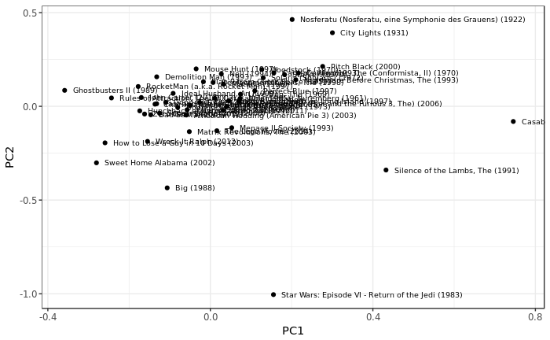

```r
set.seed(12345)
scores_df_samp = scores_df %>% sample_n(50)
ggplot(scores_df_samp) + geom_point(aes(x = PC1, y = PC2)) +
    geom_text(aes(x = PC1, y = PC2, label = title), size = 2.5, hjust = 0, nudge_x = 0.02) +
     theme_bw()
```